```python
!pip install statsmodels
```

```
     ━━━━━━━━━━━━━━━━━━━━━━━━━━━━━━━━━━━━━━━━ 10.8/10.8 MB 60.9 MB/s eta 0:00:00
     ━━━━━━━━━━━━━━━━━━━━━━━━━━━━━━━━━━━━━━ 233.9/233.9 kB 28.8 MB/s eta 0:00:00
```

# Taller 5: Forecasting

- Juan Guayara
- Daniel Oviedo

```python
import numpy as np
import pandas as pd
import matplotlib.pyplot as plt
```

# 1. Cargue en un dataframe el archivo global_economy.csv disponible en este repositorio https://github.com/jpospinalo/time-series/tree/main

```python
# Cargar dataframe global_economy.csv

rawGlobalEconomy = "https://raw.githubusercontent.com/jpospinalo/time-series/refs/heads/main/global_economy.csv"
dfGlobalEconomy = pd.read_csv(rawGlobalEconomy)
dfGlobalEconomy
```

|  | Unnamed: 0 | Country | Code | Year | GDP | Growth | CPI | Imports | Exports | Population |
| --- | --- | --- | --- | --- | --- | --- | --- | --- | --- | --- |
| 0 | 1 | Afghanistan | AFG | 1960 | 5.377778e+08 | NaN | NaN | 7.024793 | 4.132233 | 8996351.0 |
| 1 | 2 | Afghanistan | AFG | 1961 | 5.488889e+08 | NaN | NaN | 8.097166 | 4.453443 | 9166764.0 |
| 2 | 3 | Afghanistan | AFG | 1962 | 5.466667e+08 | NaN | NaN | 9.349593 | 4.878051 | 9345868.0 |
| 3 | 4 | Afghanistan | AFG | 1963 | 7.511112e+08 | NaN | NaN | 16.863910 | 9.171601 | 9533954.0 |
| 4 | 5 | Afghanistan | AFG | 1964 | 8.000000e+08 | NaN | NaN | 18.055555 | 8.888893 | 9731361.0 |
| ... | ... | ... | ... | ... | ... | ... | ... | ... | ... | ... |
| 15145 | 15146 | Zimbabwe | ZWE | 2013 | 1.909102e+10 | 1.989493 | 109.079488 | 36.668735 | 21.987759 | 15054506.0 |
| 15146 | 15147 | Zimbabwe | ZWE | 2014 | 1.949552e+10 | 2.376929 | 108.847215 | 33.741470 | 20.930146 | 15411675.0 |
| 15147 | 15148 | Zimbabwe | ZWE | 2015 | 1.996312e+10 | 1.779873 | 106.224541 | 37.588635 | 19.160176 | 15777451.0 |
| 15148 | 15149 | Zimbabwe | ZWE | 2016 | 2.054868e+10 | 0.755869 | 104.560626 | 31.275493 | 19.943532 | 16150362.0 |
| 15149 | 15150 | Zimbabwe | ZWE | 2017 | 2.204090e+10 | 4.704035 | 105.511849 | 30.370273 | 19.658023 | 16529904.0 |

15150 rows × 10 columns

# 2. Genere una nueva columna llamada "*GDP_per_capita*" dividiendo cada uno de los valores de GDP por la población

```python
dfGlobalEconomy['GDP_per_capita'] = dfGlobalEconomy['GDP'] / dfGlobalEconomy['Population']

dfGlobalEconomy.head()
```

|  | Unnamed: 0 | Country | Code | Year | GDP | Growth | CPI | Imports | Exports | Population | GDP_per_capita |
| --- | --- | --- | --- | --- | --- | --- | --- | --- | --- | --- | --- |
| 0 | 1 | Afghanistan | AFG | 1960 | 5.377778e+08 | NaN | NaN | 7.024793 | 4.132233 | 8996351.0 | 59.777327 |
| 1 | 2 | Afghanistan | AFG | 1961 | 5.488889e+08 | NaN | NaN | 8.097166 | 4.453443 | 9166764.0 | 59.878153 |
| 2 | 3 | Afghanistan | AFG | 1962 | 5.466667e+08 | NaN | NaN | 9.349593 | 4.878051 | 9345868.0 | 58.492874 |
| 3 | 4 | Afghanistan | AFG | 1963 | 7.511112e+08 | NaN | NaN | 16.863910 | 9.171601 | 9533954.0 | 78.782758 |
| 4 | 5 | Afghanistan | AFG | 1964 | 8.000000e+08 | NaN | NaN | 18.055555 | 8.888893 | 9731361.0 | 82.208444 |

# 3. Genere un nuevo dataframe únicamente con las columnas “Year”, “Country”, “GDP”, “Population” y “GDP_per_capita”

```python
dfNewGlobalEconomy = dfGlobalEconomy[['Year', 'Country', 'GDP', 'Population', 'GDP_per_capita']]
```

```python
# Convertir columna Country a mayuscula
dfNewGlobalEconomy['Country'] = dfNewGlobalEconomy['Country'].str.upper()
dfNewGlobalEconomy
```

|  | Year | Country | GDP | Population | GDP_per_capita |
| --- | --- | --- | --- | --- | --- |
| 0 | 1960 | AFGHANISTAN | 5.377778e+08 | 8996351.0 | 59.777327 |
| 1 | 1961 | AFGHANISTAN | 5.488889e+08 | 9166764.0 | 59.878153 |
| 2 | 1962 | AFGHANISTAN | 5.466667e+08 | 9345868.0 | 58.492874 |
| 3 | 1963 | AFGHANISTAN | 7.511112e+08 | 9533954.0 | 78.782758 |
| 4 | 1964 | AFGHANISTAN | 8.000000e+08 | 9731361.0 | 82.208444 |
| ... | ... | ... | ... | ... | ... |
| 15145 | 2013 | ZIMBABWE | 1.909102e+10 | 15054506.0 | 1268.126633 |
| 15146 | 2014 | ZIMBABWE | 1.949552e+10 | 15411675.0 | 1264.983826 |
| 15147 | 2015 | ZIMBABWE | 1.996312e+10 | 15777451.0 | 1265.294413 |
| 15148 | 2016 | ZIMBABWE | 2.054868e+10 | 16150362.0 | 1272.335450 |
| 15149 | 2017 | ZIMBABWE | 2.204090e+10 | 16529904.0 | 1333.395663 |

15150 rows × 5 columns

## Ver datos faltantes y rellenarlos con interpolación

Cuando tenemos puntos de datos faltantes en una serie temporal o un conjunto de datos, la interpolación busca generar un valor plausible para esos puntos con base en los valores vecinos conocidos.

```python
dfNewGlobalEconomy.isna().sum()
```

```
Year                 0
Country              0
GDP               3322
Population           3
GDP_per_capita    3325
dtype: int64
```

```python
dfNewGlobalEconomy.interpolate(method='linear', inplace=True)
dfNewGlobalEconomy.isna().sum()
```

```
Year              0
Country           0
GDP               0
Population        0
GDP_per_capita    0
dtype: int64
```

# 4. Visualice la serie de tiempo para los valores del ***GDP_per_capita*** para Suecia

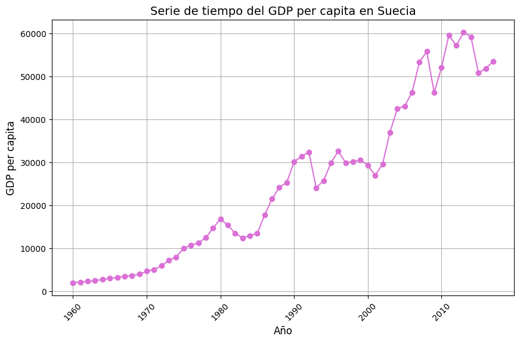

```python
serieTiempoSuecia = dfNewGlobalEconomy[dfNewGlobalEconomy['Country'] == 'SWEDEN']

# Serie de tiempo
plt.figure(figsize=(10, 6))
plt.plot(serieTiempoSuecia['Year'], serieTiempoSuecia['GDP_per_capita'], marker='o', color='orchid')
plt.title('Serie de tiempo del GDP per capita en Suecia', fontsize=14)
plt.xlabel('Año', fontsize=12)
plt.ylabel('GDP per capita', fontsize=12)
plt.grid(True)
plt.xticks(rotation=45)
plt.show()
```

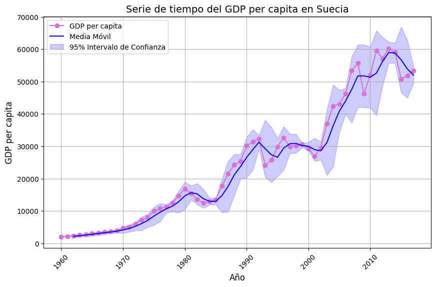

```python
serieTiempoSuecia['rolling_mean'] = serieTiempoSuecia['GDP_per_capita'].rolling(window=3).mean()
serieTiempoSuecia['rolling_std'] = serieTiempoSuecia['GDP_per_capita'].rolling(window=3).std()

plt.figure(figsize=(10, 6))
plt.plot(serieTiempoSuecia['Year'], serieTiempoSuecia['GDP_per_capita'], marker='o', color='orchid', label='GDP per capita')
plt.plot(serieTiempoSuecia['Year'], serieTiempoSuecia['rolling_mean'], color='blue', label='Media Móvil')
plt.fill_between(serieTiempoSuecia['Year'],
                 serieTiempoSuecia['rolling_mean'] - 1.96 * serieTiempoSuecia['rolling_std'],
                 serieTiempoSuecia['rolling_mean'] + 1.96 * serieTiempoSuecia['rolling_std'],
                 color='blue', alpha=0.2, label='95% Intervalo de Confianza')

plt.title('Serie de tiempo del GDP per capita en Suecia', fontsize=14)
plt.xlabel('Año', fontsize=12)
plt.ylabel('GDP per capita', fontsize=12)
plt.grid(True)
plt.legend()
plt.xticks(rotation=45)
plt.show()
```

# 5. Consulte en qué consisten los residuales de un modelo de regresión. ¿Qué distribución de probabilidad se asume usualmente para los residuales? Explique la razón.

Los residuales en un modelo de regresión es la diferencia entre los valores reales u observados y los valores predichos por el modelo.

**Residual** = **Valor Observado** - **Valor Predicho**

Estos residuales indican que tan bien el modelo se ajusta a los datos.

- Si el modelo es bueno y realiza las predicciones con presición, los residuales deberian de ser pequeños y distribuidos aleatoriamente.

Para su distribución de probabilidad, se asume una disgtribucion normal con una media de 0, basandose en el teorema del limite central, donde dice que bajo ciertas condiciones a suma de muchas variables aleatorias independientes y distribuidas de manera similar tiende a una distribución normal, incluso si las variables originales no son normales.